# Machine Learning Coursera Project

## Project Goal

Predict the manner in which 6 participants perform barbell lifts (correctly or incorrectly).The participants wore accelerometers on the belt, forearm, arm, and dumbell and were asked to perform the lifts correctly and incorrectly in 5 different ways.

The outcome variable is the “classe” variable in the training set. A is a correct movement, B,C,D,E are incorrect movements.

Questions this report will answer:  
1) How I built my model 2) How I used cross validation 3) What I think the expected out of sample error is 4) Why I made the choices I did

I will also use my prediction model to predict 20 different test cases.

The project will be published in the form of an Rmarkdown file and the accompanying HTML file from Github.

## Data

The data came from this source: http://groupware.les.inf.puc-rio.br/har

```r
training_data <- "https://d396qusza40orc.cloudfront.net/predmachlearn/pml-training.csv"
testing_data <- "https://d396qusza40orc.cloudfront.net/predmachlearn/pml-testing.csv"
training <- read.csv("training.csv")
data <- training
testing <- read.csv("testing.csv")
```

## test set

lets make a factor of 40% of the data to use as an internal test set

```r
library(caret)
set.seed(3333)
inTrain <- createDataPartition(y=training$classe,p=0.6,list=FALSE)
```

## Feature Selection

Now it is time to explore the predictors.

```
##   [1] "X"                        "user_name"
##   [3] "raw_timestamp_part_1"     "raw_timestamp_part_2"
##   [5] "cvtd_timestamp"           "new_window"
##   [7] "num_window"               "roll_belt"
##   [9] "pitch_belt"               "yaw_belt"
##  [11] "total_accel_belt"         "kurtosis_roll_belt"
##  [13] "kurtosis_picth_belt"      "kurtosis_yaw_belt"
##  [15] "skewness_roll_belt"       "skewness_roll_belt.1"
##  [17] "skewness_yaw_belt"        "max_roll_belt"
##  [19] "max_picth_belt"           "max_yaw_belt"
##  [21] "min_roll_belt"            "min_pitch_belt"
##  [23] "min_yaw_belt"             "amplitude_roll_belt"
##  [25] "amplitude_pitch_belt"     "amplitude_yaw_belt"
##  [27] "var_total_accel_belt"     "avg_roll_belt"
##  [29] "stddev_roll_belt"         "var_roll_belt"
```

[output cut: 65 more lines]

```
## 'data.frame':    19622 obs. of  160 variables:
##  $ X                       : int  1 2 3 4 5 6 7 8 9 10 ...
##  $ user_name               : Factor w/ 6 levels "adelmo","carlitos",..: 2 2 2 2 2 2 2 2 2 2 ...
##  $ raw_timestamp_part_1    : int  1323084231 1323084231 1323084231 1323084232 1323084232 1323084232 1323084232 1323084232 1323084232 1323084232 ...
##  $ raw_timestamp_part_2    : int  788290 808298 820366 120339 196328 304277 368296 440390 484323 484434 ...
##  $ cvtd_timestamp          : Factor w/ 20 levels "2/12/2011 13:32",..: 15 15 15 15 15 15 15 15 15 15 ...
##  $ new_window              : Factor w/ 2 levels "no","yes": 1 1 1 1 1 1 1 1 1 1 ...
##  $ num_window              : int  11 11 11 12 12 12 12 12 12 12 ...
##  $ roll_belt               : num  1.41 1.41 1.42 1.48 1.48 1.45 1.42 1.42 1.43 1.45 ...
##  $ pitch_belt              : num  8.07 8.07 8.07 8.05 8.07 8.06 8.09 8.13 8.16 8.17 ...
##  $ yaw_belt                : num  -94.4 -94.4 -94.4 -94.4 -94.4 -94.4 -94.4 -94.4 -94.4 -94.4 ...
##  $ total_accel_belt        : int  3 3 3 3 3 3 3 3 3 3 ...
##  $ kurtosis_roll_belt      : Factor w/ 397 levels "","-0.01685",..: 1 1 1 1 1 1 1 1 1 1 ...
##  $ kurtosis_picth_belt     : Factor w/ 317 levels "","-0.021887",..: 1 1 1 1 1 1 1 1 1 1 ...
##  $ kurtosis_yaw_belt       : Factor w/ 2 levels "","#DIV/0!": 1 1 1 1 1 1 1 1 1 1 ...
```

[output cut: 86 more lines]

# making all rows numeric

all predictors are numeric but were not read in as such

```r
cols = c(-1,-2,-3,-4,-5,-6,-7,-160);
training[,cols] = apply(training[,cols], 2, function(x) as.numeric(as.character(x)))
```

```
## Warning in FUN(newX[, i], ...): NAs introduced by coercion
```

```
## Warning in FUN(newX[, i], ...): NAs introduced by coercion
```

```
## Warning in FUN(newX[, i], ...): NAs introduced by coercion
```

```r
testing[,cols] = apply(testing[,cols], 2, function(x) as.numeric(as.character(x)))
```

based in the warning messages, its clear that we have missing values in the training set that we will need to deal with. Note: at this point we have already identified that 1:7 and 160 (our outcome) will not be used to train our model.

# Near Zero Variance

Next step in figuring out which variables to usee is to check for near zero variance.

```r
nzv <- nearZeroVar(training,saveMetrics=TRUE)
```

amplitude_yaw_belt, amplitude_yaw_dumbbell, amplitude_yaw_forearm will be excluded from further analysis due to near zero variance. Note: now we have identified that we will be excluding 1:7, 26, 101, 139

# Too Many NAs

some variables require imputation, but there others that have too many missing values to be useful. If more than 30% of the data points are missing, we will exclude them from model fitting.

```r
NA_percent <- function(x) {length(na.omit(x))/length(x)}
NA_training <- c()
NA_names <- names(training)
for (i in 1:ncol(training)) {
  test <- training[,i]
  result <- NA_percent(test)
  NA_training <- c(NA_training,result)
}
percents <- cbind(NA_names,NA_training)
percents <- as.data.frame(percents)
names_exclude <- percents[NA_training < .7,]
names_exclude[,1] <- as.character(names_exclude[,1])
names_exclude <- names_exclude[,1]
names_exclude <- which(names(training) %in% names_exclude)
names_exclude <- c(1:7,names_exclude,26,101,139)
names_exclude <- unique(names_exclude)
```

now we have a vector names names_exclude that has the number corresponding to all columns we want to ignore during modelling. We have removed variables with excessive NAs, near zero variance, and those that are identifiers. Now we are ready to explore the rest of the variables more deeply to see if we can learn a bit more.

# Feature Plotting

lets start by checking out the first four predictors left, 8:11

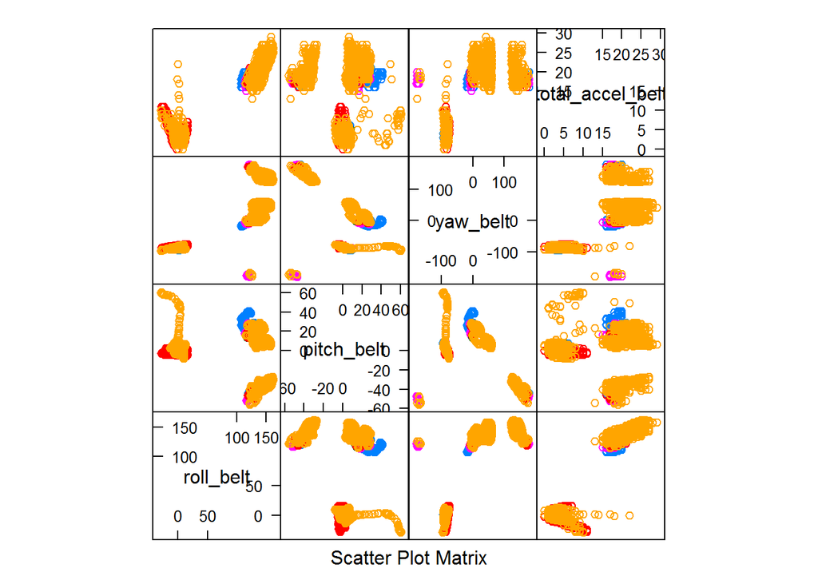

```r
featurePlot(x=training[,c(8:11)],y=training$classe,plot="pairs")
```

error type E has large variance across all of the variables.

# Train and Validate set made

```r
train <- training[inTrain,c(-names_exclude)]
validate <- training[-inTrain,c(-names_exclude)]
test <- testing[,c(-names_exclude)]
```

at this point we have three sets of data. The base test set, the validation set which is a partition of the original training data, and the train data that will be used to make our models.

# accuracy function

I made my own accuracy function which compares the predicted and real outcomes

```r
accuracy <- function(x,y) {length(which(x==y))/length(x)}
```

# Centering and Scaling

I want to have one set of data that is center and scaled in order to see how this changes the accuracy of our tests.

```r
preObj <- preProcess(train[,c(-53)],method=c("center","scale"))
trainScale <- predict(preObj,train[,c(-53)])
trainScale$classe <- train$classe
validateScale <- predict(preObj,validate[,c(-53)])
validateScale$classe <- validate$classe
testScale <- predict(preObj,test[,c(-53)])
testScale$problem_id <- test$problem_id
```

now there is a center and scaled data set of the 52 predictors of interest.

# Predicting with a decision tree

```r
mod1 <- train(classe~.,method="rpart",data=train)
pred1 <- predict(mod1,newdata=validate)
accuracy(pred1,validate$classe)
```

```
## [1] 0.4950293
```

```r
mod7 <- train(train$classe~.,method="lda",data=train)
pred7 <- predict(mod7,newdata=validate)
accuracy(pred7,validate$classe)
```

```
## [1] 0.6995921
```

# pre process with PCA

```r
prePCA <- preProcess(train[,c(-53)],method="pca")
PCA5train <- predict(prePCA,newdata=train[,c(-53)])
mod5 <- train(train$classe~.,method="rf",data=PCA5train)
PCA5validate <- predict(prePCA,newdata=validate[,c(-53)])
pred5 <- predict(mod5,newdata=PCA5validate)
accuracy(pred5,validate$classe)
```

```
## [1] 0.9720877
```

# Test Prediction

Model 5 will be used to predict on the test set.

```r
PCA5test <- predict(prePCA,newdata=test[,c(-53)])
pred_test1 <- predict(mod5,newdata=PCA5test)
answers <- as.character(pred_test1)
```